# Mayzent principal stratum analysis

Baldur Magnusson

01/20/2021

# Introduction

This vignette demonstrates how to use the data provided in the online supplement of [2] (“the paper”) to reproduce the corresponding main results shown in figures 1 and 2.

The following steps are involved:

- Read the data into a format that is usable by R (data frame)
- Read the Stan program and inspect the various program blocks that comprise the overall model
- Compile and run the Stan model
- Post-process and summarize the outputs

First load the required packages.

```r
library(tidyverse)
library(rstan)
library(bayesplot)
```

# Data

The first step is to enter the data as provided in the online supplement of the paper. We use a `trt_vec` vector for easy reference to the two treatment arms. Note this data corresponds to the month 12 timepoint.

```r
trt_vec <- c("baf","pbo")

base_data <- data.frame(covstr=c(1,2,3,4),
                        rand=c(315,455,275,596))

res_data <- data.frame(covstr=sort(rep(1:4,4)),
                       rel=rep(c(0,0,1,1),4),
                       trt=rep(trt_vec,8),
                       avail=c(145,68,22,13,221,109,15,17,125,63,20,11,304,130,13,7),
                       cdp=c(25,15,5,7,44,26,7,9,13,14,7,4,56,19,5,1))
```

# Stan model

For a detailed introduction to the Stan programming language, the reader can refer to [1] or [3].

A typical Stan program is divided into several programming blocks:

- `functions:` User-defined functions (not used in our program)
- `data`: Declaration of all the data required by our model that will be passed to Stan from the calling program, e.g. `R`
- `transformed data`: Declaration and definition of constants and transformed data (not used in our program)
- `parameters`: Declaration of model parameters
- `transformed parameters`: Declaration and definition of variables that are functions of other variables and/or data
- `model`: Definition of prior distributions and likelihood
- `generated quantities`: Derived quantities based on parameters, data, and (optionally) pseudo random number generation

We will look at each block of our program and discuss specifics that might not be obvious from merely reading the code. The entire program is printed in the appendix.

## `data` block

```r
data {
  // --- Scalars and summary vectors
  int<lower=1>              Ntrt;                   // Number of treatments
  int<lower=1>              Nstr;                   // Number of principal strata
  int<lower=1>              Ncat;                   // Number of strata observation categories (e.g. IH)
  int<lower=1>              Nx;                     // Number of covariate strata
  vector[Nx]                px;                     // P(X=x), proportion of patients with X=x

  // --- Individual level data
  int<lower=1>              Ni;                     // number of individual observations
  int<lower=1, upper=4>     cat[Ni];                // relapse by treatment category for principal strata
  int<lower=0, upper=1>     Di[Ni];                 // disability indicators (confirmed)
  int<lower=1, upper=Nx>    Xstr[Ni];               // Covariate stratum for each patient

  // --- Prior parameters
  vector[2]                 alpha_prior;            // alpha priors
  vector[2]                 alpha_H_prior;          // prior to use specifically for harmed stratum
  vector[2]                 theta_pbo_prior[Nstr];  // theta placebo priors
  vector[2]                 delta_prior[Nstr];      // delta prior parms

  // --- Utility data for run management, not used for modeling
  int<lower=0, upper=1>     ind_prior;              // indicator for th0 \perp th1 priors or th1 = th0 + delta priors
  int<lower=0, upper=1>     use_data;               // indicator as to whether to sample from prior or posterior

  // --- Various constant indices useful for code readability
  int                       IMM;
  int                       DOO;
  int                       BEN;
  int                       HAR;
  int                       DB;                     // doomed or benefiter
  int                       DH;                     // doomed or harmed
  int                       IB;                     // immune or benefiter
  int                       IH;                     // immune or harmed
  int                       PBO;
  int                       BAF;

}
```

Extensive comments should make the purpose of each variable reasonably clear. Notes:

- Stan is strongly typed, so when declaring a variable, e.g. `Ntrt`, we have to specify its type (`int`) and, in the case of multi-dimensional variables, e.g. `px`, the dimension
- A few variables pertain to individual level data. Since the data in table 2 was provided at the summary level, we will have to convert to individual level data before fitting the model
- Some of the variables, e.g. `px` or `Di`, correspond to actual clinical data whereas other variables such as `ind_prior` are “control variables” in the sense that they will direct behavior of the program at run-time
- Parameters to the prior distributions are also passed as data which is favorable to hard coding in the program, for example to facilitate easy execution of sensitivity analyses

## `parameters` block

```r
parameters {
  // alpha parmeters refer to principal strata (relapse)
  vector[Nx] alpha_D;
  vector[Nx] alpha_I;
  vector[Nx] alpha_H;

  // theta and delta parameters refer to disability
  vector[Nx] theta_pbo[Nstr];
  vector[Nx] delta[Nstr];

}
```

This block is straightforward. We declare parameters corresponding to the principal strata, one parameter per principal stratum and covariate stratum combination. These are the $\alpha_{g,x}$ in the notation of the paper. We also define separate vectors by principal stratum. The disability rate parameters are declared similarly, i.e. by principal stratum and covariate stratum.

## `transformed parameters` block

```r
transformed parameters {
  vector[Nstr]              alpha[Nx];
  matrix[Nstr,Ntrt]         theta[Nx];

  for (x in 1:Nx) {
    alpha[x,IMM] = alpha_I[x];
    alpha[x,DOO] = alpha_D[x];
    alpha[x,HAR] = alpha_H[x];
    alpha[x,BEN] = 0;

    for (s in 1:Nstr) {
      theta[x,s,PBO] = theta_pbo[s,x];
      if (ind_prior == 1) {
        theta[x,s,BAF] = delta[s,x];
      } else {
        theta[x,s,BAF] = theta_pbo[s,x] + delta[s,x];
      }
    }
  }
}
```

In this block, we declare the two variables that will feed into the likelihood in the `model` block, `alpha` and `theta`. The variable `alpha` is an array of vectors and `theta` is an array of matrices.

Notes:

- Every entry of `alpha[x,BEN]` is set to zero. This is the identifiability constraint of the softmax function, referred to in section 4 of the paper
- Note use of the control variable `ind_prior`, where `theta` corresponding to active treatment (`BAF`) is set as `delta` in the case of independent parameterization for treatment effect, or set as `theta_pbo + delta` for dependent parameterization

## `model` block

The `model` block is relatively large and for ease of exposition split it into two parts.

```r
model {
  alpha_D ~ normal(alpha_prior[1],alpha_prior[2]);
  alpha_I ~ normal(alpha_prior[1],alpha_prior[2]);
  alpha_H ~ normal(alpha_H_prior[1],alpha_H_prior[2]);

  theta_pbo[IMM] ~ normal(theta_pbo_prior[IMM,1],theta_pbo_prior[IMM,2]);
  theta_pbo[DOO] ~ normal(theta_pbo_prior[DOO,1],theta_pbo_prior[DOO,2]);
  theta_pbo[BEN] ~ normal(theta_pbo_prior[BEN,1],theta_pbo_prior[BEN,2]);
  theta_pbo[HAR] ~ normal(theta_pbo_prior[HAR,1],theta_pbo_prior[HAR,2]);
  delta[IMM] ~ normal(delta_prior[IMM,1],delta_prior[IMM,2]);
  delta[DOO] ~ normal(delta_prior[DOO,1],delta_prior[DOO,2]);
  delta[BEN] ~ normal(delta_prior[BEN,1],delta_prior[BEN,2]);
  delta[HAR] ~ normal(delta_prior[HAR,1],delta_prior[HAR,2]);
```

The first chunk of code specifies prior distributions for all parameters of the model (i.e. all parameters specified in the `parameters` block). Every parameter is assigned a normal prior, with specific parameters as specified in the input to the program. Note that if we do not specify a prior here, Stan will automatically assign a uniform prior on the unconstrained space (it is recommended to always specify your own priors).

```r
  {
    int xi;
    int ci;

    vector[Ni]     rprob;
    vector[Ni]     dprob;
    vector[Ncat]   mix_weight[Nx];
    vector[Nstr]  pi_temp;

    if (use_data == 1) {

      for (x in 1:Nx) {
        pi_temp = softmax(alpha[x]);
        mix_weight[x,IH] = pi_temp[IMM]/(pi_temp[IMM]+pi_temp[HAR]);
        mix_weight[x,IB] = pi_temp[IMM]/(pi_temp[IMM]+pi_temp[BEN]);
        mix_weight[x,DH] = pi_temp[DOO]/(pi_temp[DOO]+pi_temp[HAR]);
        mix_weight[x,DB] = pi_temp[DOO]/(pi_temp[DOO]+pi_temp[BEN]);
      }

      for (i in 1:Ni) {
        ci = cat[i];
        xi = Xstr[i];

        if (ci==IH) {
          // immune or harmed, placebo
          rprob[i] = log_sum_exp(categorical_logit_lpmf(IMM | alpha[xi]),
                                 categorical_logit_lpmf(HAR | alpha[xi]));
          dprob[i] = log_mix(mix_weight[xi,ci],
                             bernoulli_logit_lpmf(Di[i] | theta[xi,IMM,PBO]),
                             bernoulli_logit_lpmf(Di[i] | theta[xi,HAR,PBO]));
        } else if (ci==IB) {
          // immune or benefiter, experimental
          rprob[i] = log_sum_exp(categorical_logit_lpmf(IMM | alpha[xi]),
                                 categorical_logit_lpmf(BEN | alpha[xi]));
          dprob[i] = log_mix(mix_weight[xi,ci],
                             bernoulli_logit_lpmf(Di[i] | theta[xi,IMM,BAF]),
                             bernoulli_logit_lpmf(Di[i] | theta[xi,BEN,BAF]));
        } else if (ci==DH) {
          // doomed or harmed, experimental
          rprob[i] = log_sum_exp(categorical_logit_lpmf(DOO | alpha[xi]),
                                 categorical_logit_lpmf(HAR | alpha[xi]));
          dprob[i] = log_mix(mix_weight[xi,ci],
                             bernoulli_logit_lpmf(Di[i] | theta[xi,DOO,BAF]),
                             bernoulli_logit_lpmf(Di[i] | theta[xi,HAR,BAF]));
        } else {
          // doomed or benefiter, placebo
          rprob[i] = log_sum_exp(categorical_logit_lpmf(DOO | alpha[xi]),
                                 categorical_logit_lpmf(BEN | alpha[xi]));
          dprob[i] = log_mix(mix_weight[xi,ci],
                             bernoulli_logit_lpmf(Di[i] | theta[xi,DOO,PBO]),
                             bernoulli_logit_lpmf(Di[i] | theta[xi,BEN,PBO]));
        }
      }
      target += rprob;
      target += dprob;
    }
  }
}
```

The first for loop calculates the current value of $\pi_x$, corresponding to the current sample from the posterior, using the `softmax` function and also the mixture weights that are used in specification of the disability model likelihood. Refer to Table 1 of the paper.

The second for loop goes through all individual observations and calculates the log probability density function based on the observed data. (Incrementing the log probability density function is the basis of execution of a Stan program – refer to the Stan manual [3] for details). `rprob` and `dprob` are vectors of log probabilities for each observation, corresponding to observed relapses and observed disability progressions, respectively. The parameters that apply for each vector entry depend on the corresponding treatment assignment and observed value for relapse (Table 1 of the paper).

In the first if-statement clause (`IH`, i.e. immune or harmed, i.e. $(S,Z)=(0,0)$), the likelihood contribution for the relapse model is would therefore be written in terms of the sum of probabilities from a categorical distribution ($\pi_I$ and $\pi_H$). One could simply write `rprob[i] = pi_temp[IMM] + pi_temp[HAR]` but, because the Stan sampler is most efficient on an unconstrained space, we use the log probability mass function (`_lpmf`) for the logit-scaled categorical distribution. The function `log_sum_exp(x)` is simply a computationally stable function that returns the logarithm of the sum of the exponentials of the elements in `x`. For disability progressions, the log probability is updated with the log mixture of the log Bernoulli probability mass functions corresponding to the two principal strata that apply. The mixture weight `mix_weight` was calculated in the code block shown previously.

Minor notes:

- The lone curly braces surrounding this code are used so that variables declared within are not saved for post-processing (saves space)
- If `use_data` is set to zero, this chunk will not execute, and the program will only sample from the prior. This is a useful flag to include in your program as it allows to easily switch between prior and posterior sampling without writing any additional code.
- The statements `target += rprob` and `target += dprob` increment the log probability based on the values assigned to `rprob` and `dprob` in this iteration of the sampler

## The `generated quantities` block

```r
generated quantities {
  vector[Nstr]          th_PS[Ntrt]; // Disability prob. for the immune stratum
  simplex[Nstr]         pi;   // Principal strata probabilities
  vector[Nstr]          rr_PS; // relative risk for immune popn.
  vector[Ntrt]          th_O; // disability probability for the whole population
  real                  rr_O; // relative risk for the whole population

  // In here we implement standardization (average of model-predicted
  // probability weighted by covariate combination)
  {
    real          temp_pi[Nstr,Nx];
    real          temp_th[Ntrt,Nstr,Nx];
    real          temp_th_O[Nstr];
    vector[Nstr]  temp_sa;

    // For P(Stratum=s)
    for (s in 1:Nstr) {
      for (x in 1:Nx) {
        temp_sa = softmax(alpha[x]);
        // note temp_sa is covariate-specific, i.e. changes with x
        temp_pi[s,x] = temp_sa[s]*px[x];
      }
      pi[s] = sum(temp_pi[s]);
    }

    // For P(D(z) = 1 | S)
    for (z in 1:Ntrt) {
      for (s in 1:Nstr) {
        for (x in 1:Nx) {
          temp_th[z,s,x] = inv_logit(theta[x,s,z])*temp_pi[s,x];
        }
        th_PS[z,s] = sum(temp_th[z,s])/pi[s];
        temp_th_O[s] = th_PS[z,s]*pi[s];
      }
      th_O[z] = sum(temp_th_O);
    }

    for (s in 1:Nstr) {
      rr_PS[s] = th_PS[BAF,s]/th_PS[PBO,s];
    }
    rr_O = th_O[BAF]/th_O[PBO];
  }
}
```

In this block we implement the standardization calculations to derive the marginal quantities $\pi_g$ and $\theta_g$ defined in section 4 of the paper. The standardization formulae are given in Equation (4).

# Pre-processing

Prepare data for sampling. This involves converting the summary data to individual-level data as mentioned above. For this we use the `by_row` function from the `purrrlyr` package.

```r
# reference data frames
ps_names <- c("IMM", "DOO", "BEN", "HAR")
ps_df <- data.frame(psn = 1:4, ps = factor(ps_names, levels = ps_names))
Nx <- max(res_data$covstr)
rel_ps <- data.frame(rel = c(0,0,1,1),
                     trt = rep(rev(trt_vec), 2),
                     ps = c(1,2,3,4),
                     str = c("IH", "IB", "DB", "DH"))

px_data <- base_data %>% mutate(px = rand/sum(rand))

# convert the summary data into individual level data for sampling in Stan
adata <- res_data %>% purrrlyr::by_row(function(x) {
    data.frame(ri = rep(x$rel, x$avail),
               di = c(rep(1, x$cdp), rep(0, x$avail - x$cdp)))
  }, .collate = "rows")  %>%
  select(covstr, trt, rel = ri, cdp = di) %>%
  inner_join(rel_ps, by = c("rel","trt"))

# the th_prior mean is based on a two-year expected disability rate, so we adjust to one year
# (since the analysis is for the 12 month time point) using an exponential distribution
th_prior <- c(0.3, 2)
th_la <- -log(1 - th_prior[1])/2 # lambda is the year rate
p0 <- pexp(1, rate = th_la) # p0 = P(exp < 1 year) w/the lambda suggested by two year prob. of 0.3
lm0 <- log(p0/(1-p0)) # prior mean is on the logit scale

standat <- list(Ntrt = length(trt_vec),
                Nstr = length(ps_names),
                Ncat = max(rel_ps$ps),
                Nx = Nx,
                px = as.numeric(px_data$px),
                Ni = sum(res_data$avail),
                cat = adata$ps,
                Di = adata$cdp,
                Xstr = adata$covstr,
                alpha_prior = c(0, 2),
                alpha_H_prior = c(-50, 0.1),
                theta_pbo_prior = matrix(c(rep(lm0, Nx), rep(th_prior[2], Nx)), ncol = 2),
                delta_prior = matrix(c(rep(0, Nx), rep(2, Nx)), ncol = 2),
                ind_prior = 0,
                use_data = 1,
                IMM = ps_df$psn[ps_df$ps == "IMM"], DOO = ps_df$psn[ps_df$ps == "DOO"],
                BEN = ps_df$psn[ps_df$ps == "BEN"], HAR = ps_df$psn[ps_df$ps == "HAR"],
                IB = rel_ps$ps[rel_ps$str == "IB"], DB = rel_ps$ps[rel_ps$str == "DB"],
                IH = rel_ps$ps[rel_ps$str == "IH"], DH = rel_ps$ps[rel_ps$str == "DH"],
                BAF = 1, PBO = 2
)
```

# Sampling & post-processing

We are now ready to compile and sample from our model. Note the use of multiple cores to parallelize the individual chains.

```r
mod <- stan_model("PS_model.stan") # compiles the model

options(mc.cores = parallel::detectCores())
fit <- sampling(mod, data=standat, seed=9, iter=2000)
```

Let’s restrict our attention to two key parameter vectors, `pi` and `rr_PS`.

```r
par_out <- c("pi", "rr_PS")
print(fit, pars=par_out)
```

```
## Inference for Stan model: PS_model.
## 4 chains, each with iter=2000; warmup=1000; thin=1;
## post-warmup draws per chain=1000, total post-warmup draws=4000.
##
##          mean se_mean   sd 2.5%  25%  50%  75% 97.5% n_eff Rhat
## pi[1]    0.87    0.00 0.01 0.84 0.86 0.87 0.88  0.90  3590    1
## pi[2]    0.08    0.00 0.01 0.06 0.07 0.08 0.08  0.09  3936    1
## pi[3]    0.05    0.00 0.01 0.03 0.04 0.05 0.06  0.08  2947    1
## pi[4]    0.00    0.00 0.00 0.00 0.00 0.00 0.00  0.00  3064    1
## rr_PS[1] 0.81    0.00 0.13 0.56 0.72 0.80 0.90  1.08  3325    1
## rr_PS[2] 0.99    0.01 0.42 0.53 0.74 0.90 1.14  1.99  3066    1
## rr_PS[3] 1.17    0.01 0.55 0.32 0.83 1.11 1.41  2.53  4679    1
## rr_PS[4] 1.35    0.02 0.94 0.27 0.78 1.14 1.65  3.72  3770    1
##
## Samples were drawn using NUTS(diag_e) at Tue Jan 19 22:12:21 2021.
## For each parameter, n_eff is a crude measure of effective sample size,
## and Rhat is the potential scale reduction factor on split chains (at
## convergence, Rhat=1).
```

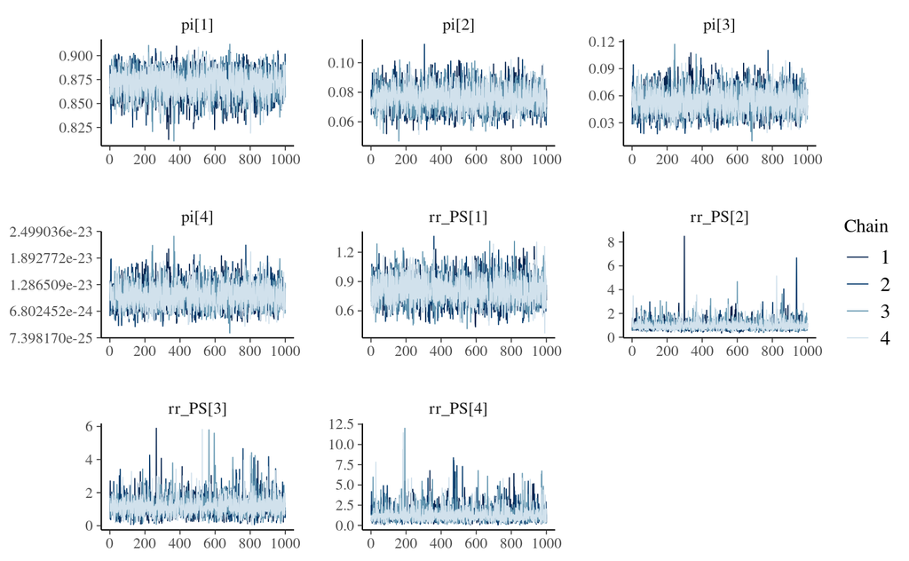

```r
mcmc_trace(as.array(fit), regex_pars=par_out)
```

An initial glance at the inference printout and trace plots does not raise any concerns (high `n_eff`, `Rhat` equal to 1, good mixing in trace plots). A number of diagnostics can (and should) be run to assess the quality of sampling, convergence, etc. For more information, the package `bayesplot` has an excellent vignette on MCMC diagnostics.

Finally, let’s visualize the estimated principal stratum proportions and the risk ratio in the non-relapser stratum.

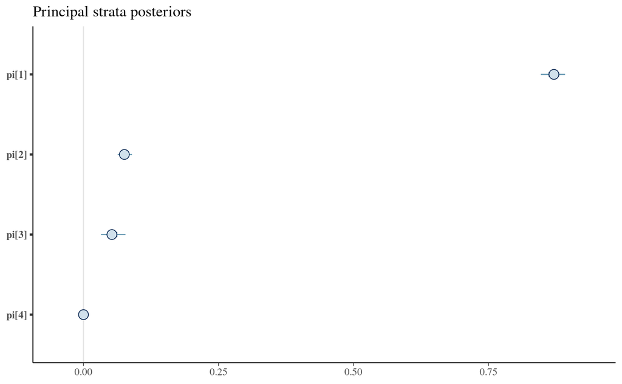

```r
mcmc_intervals(as.array(fit), regex_pars = "pi") + labs(title = "Principal strata posteriors")
```

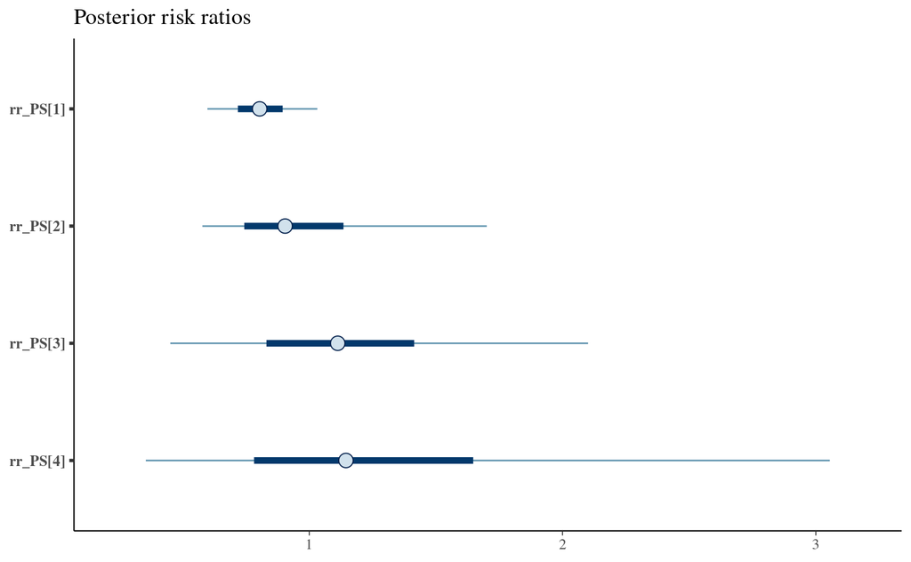

```r
mcmc_intervals(as.array(fit), regex_pars = "rr_PS") + labs(title = "Posterior risk ratios")
```

Conclusions:

- Substantial majority of patients belong ot non-relapser principal stratum
- Positive effect in non-relapser stratum (not significant), wide credibiilty intervals
- Risk ratios in benefiter and harmed strata should be mostly dismissed as they are not identifiable and mostly reflect assumptions placed on parameter distributions

# References

1. Bob Carpenter, Andrew Gelman, Matthew Hoffman, Daniel Lee, Ben Goodrich, Michael Betancourt, Marcus Brubaker, Jiqiang Guo, Peter Li, and Allen Riddell. 2017. Stan: A probabilistic programming language. *Journal of Statistical Software, Articles* 76, 1: 1–32. https://doi.org/10.18637/jss.v076.i01

2. Baldur P Magnusson, Heinz Schmidli, Nicolas Rouyrre, and Daniel O Scharfstein. 2019. Bayesian inference for a principal stratum estimand to assess the treatment effect in a subgroup characterized by postrandomization event occurrence. *Statistics in Medicine* 38, 23: 4761–4771.

3. Stan Development Team. 2018. *Stan modeling language users guide and reference manual*. Retrieved from http://mc-stan.org

# Appendix

```r
writeLines(readLines("PS_model.stan"))
```

```
## data {
##   // --- Scalars and summary vectors
##   int<lower=1>              Ntrt;                   // Number of treatments
##   int<lower=1>              Nstr;                   // Number of principal strata
##   int<lower=1>              Ncat;                   // Number of strata observation categories (e.g. IH)
##   int<lower=1>              Nx;                     // Number of covariate strata
##   vector[Nx]                px;                     // P(X=x), proportion of patients with X=x
##
##   // --- Individual level data
##   int<lower=1>              Ni;                     // number of individual observations
##   int<lower=1, upper=4>     cat[Ni];                // relapse by treatment category for principal strata
##   int<lower=0, upper=1>     Di[Ni];                 // disability indicators (confirmed)
##   int<lower=1, upper=Nx>    Xstr[Ni];               // Covariate stratum for each patient
##
##   // --- Prior parameters
##   vector[2]                 alpha_prior;            // alpha priors
##   vector[2]                 alpha_H_prior;          // prior to use specifically for harmed stratum
##   vector[2]                 theta_pbo_prior[Nstr];  // theta placebo priors
##   vector[2]                 delta_prior[Nstr];      // delta prior parms
##
##   // --- Utility data for run management, not used for modeling
##   int<lower=0, upper=1>     ind_prior;              // indicator for th0 \perp th1 priors or th1 = th0 + delta priors
##   int<lower=0, upper=1>     use_data;               // indicator as to whether to sample from prior or posterior
##
##   // --- Various constant indices useful for code readability
##   int                       IMM;
##   int                       DOO;
##   int                       BEN;
##   int                       HAR;
##   int                       DB;                     // doomed or benefiter
##   int                       DH;                     // doomed or harmed
##   int                       IB;                     // immune or benefiter
##   int                       IH;                     // immune or harmed
##   int                       PBO;
##   int                       BAF;
##
## }
## parameters {
##   // alpha parmeters refer to principal strata (relapse)
##   vector[Nx] alpha_D;
```

[output cut: 128 more lines]

```
##         for (x in 1:Nx) {
##           temp_th[z,s,x] = inv_logit(theta[x,s,z])*temp_pi[s,x];
##         }
##         th_PS[z,s] = sum(temp_th[z,s])/pi[s];
##         temp_th_O[s] = th_PS[z,s]*pi[s];
##       }
##       th_O[z] = sum(temp_th_O);
##     }
##
##     for (s in 1:Nstr) {
##       rr_PS[s] = th_PS[BAF,s]/th_PS[PBO,s];
##     }
##     rr_O = th_O[BAF]/th_O[PBO];
##   }
## }
```